Toggle Input Cells

# Californa API Analysis Examples

This IPython notebook is an example of using IPython and Ambry for analyzing Academic Performance Index scores for California, from 2000 to 2012. This data was extracted from the California Department of Education website and loaded into Ambry to create a single dataset that combines multiple years of data and harmonizes column names across the years. [An earlier version of this set](http://data.sandiegodata.org/dataset/cde_ca_gov-api-combined-429e-extract) can be downloaded from the San Diego Regional Data Library Data Repository, which also hosts the [documentation for the dataset](http://data.sandiegodata.org/storage/f/2013-11-05T211612/documentation.html).

In this example, we will show how to get datasets from an Ambry library and perform some analysis using Pandas.

## Getting Data With Ambry

Ambry is a data library and package management system that makes it much easier for analysts to get data to use in their analysis. In these first cells, we will get a library objectand look for the API dataset.

In this case, Ambry has been previously configured to connect to a remote Ambry library that hosts the dataset.

First we will construct the interactive library using ilibrary() and search for files that have 'api' in the name.

```python
import ambry
import pandas as pd
l = ambry.ilibrary()
l.find(name='api')
```

[output not shown]

The last line of the input cell, `l.find(name='api')` returns a list of records in a way that allows IPython to print it in HTML form. This is a frequently-used way to get more information about objects with using IPython Notebook.

Each of these datasets may be composed of multiple partitions, with each partition holding a part of a dataset, broken up by time, geographic location, or other factor. Now we will fetch one of the packages and look at what partitions are available.

```python
b =  l.get('cde.ca.gov-api-combined-api_base')
b
```

| **Identity** |  |
| --- | --- |
| Vid | d007004 |
| Sname | cde.ca.gov-api-combined |
| Vname | cde.ca.gov-api-combined-0.1.4 |
| Locations | L |
| **Source** |  |
| Db | /data/library/cde.ca.gov/api-combined-0.1.4.db |
| Created | 2014-04-06T17:09:23.124134 |
| Built | 2014-04-06T17:13:57.724470 |
| Build_Time | 268.45s |
| Prepared | 2014-04-06T17:09:29.127678 |
| Partitions | 2 |

When we asked for the dataset without a version number, Ambry selected the latest version and returned it. This object is also know as a "Bundle" since it provides the grouping for multiple partitions. On the last line we can see that this bundle has two partitions.

```python
b.partitions
```

| Id | Name | table |
| --- | --- | --- |
| p007001 | cde.ca.gov-api-combined-api_base | api_base |
| p007002 | cde.ca.gov-api-combined-api_growth | api_growth |

One partition in the bundle is for the base API scores, and the other is for year-to-year growth in the scores. Let's get the base partition and examine it. If you print out the `p` object, you'll get information about the partition, but we'll focus on the main table in the partition.

```python
p = l.get('cde.ca.gov-api-combined-api_base').partition
assert(p.identity.on.revision >= 4)
p.table
```

| Name | api_base |
| --- | --- |
| Id | t00701 |
| Vid | t00701004 |

| # | Name | Datatype | description |
| --- | --- | --- | --- |
| 1 | id | INTEGER |  |
| 2 | year | INTEGER | School year , from original dataset |
| 3 | cds | INTEGER64 | County/District/School code |
| 4 | stype | VARCHAR | Type: 1=Unified, 2=Elementary District, 3=9-12 High District, 4=7-12 High District, E=Elementary School, M=Middle School, H=High School |
| 5 | sname | VARCHAR | School Name |
| 6 | dname | VARCHAR | District Name |
| 7 | cname | VARCHAR | County Name |
| 8 | flag | INTEGER | Flag Values |
| 9 | api | INTEGER | [This Year] API (Base) |
| 10 | pct_test | INTEGER | Percentage of Students Tested |
| 11 | valid_num | INTEGER | Number of Students Included in the [This Year] Academic Performance Index (API) |
| 12 | st_rank | INTEGER | Statewide Rank (I=Invalid data, B=District or ASAM, C=Special Education School . ) |
| 13 | sum_rank | VARCHAR | Similar Schools Rank |
| 14 | gr_targ | INTEGER | [Next Year Range] API Growth Target (A=means the school or student group scored at or above the statewide performance target of 800 in [This Year], B=This is an LEA, C=means this is a special educatio… |
| 15 | api_targ | INTEGER | [Next Year] API Target (A=means the school or student group scored at or above the statewide performance target of 800 in [This Year], B=This is an LEA, C=means this is a special education school.) |
| 16 | aa_num | INTEGER | Number of Black or African Americans Included in API |
| 17 | aa_sig | VARCHAR | Black or African Americans Significant?(Yes/No) |
| 18 | aa_api | INTEGER | [This Year] Black or African American API (Base) |
| 19 | aa_gt | INTEGER | [Next Year Range] Black or African American student group Growth Target |
| 20 | aa_targ | INTEGER | [Next Year] Black or African American student group API Target |
| 21 | ai_num | INTEGER | Number of American Indian/Alaska Native Included in API |
| 22 | ai_sig | VARCHAR | American Indian/Alaska Native Significant?(Yes/No) |
| 23 | ai_api | INTEGER | [This Year] American Indian/Alaska Native API (Base) |
| 24 | ai_gt | INTEGER | [Next Year Range] American Indian/Alaska Native student group Growth Target |
| 25 | ai_targ | INTEGER | [Next Year] American Indian/Alaska Native student group API Target |
| 26 | as_num | INTEGER | Number of Asian Included in API |
| 27 | as_sig | VARCHAR | Asian Significant?(Yes/No) |
| 28 | as_api | INTEGER | [This Year] Asian API (Base) |
| 29 | as_gt | INTEGER | [Next Year Range] Asian student group Growth Target |
| 30 | as_targ | INTEGER | [Next Year] Asian student group API Target |

[output cut: 153 more lines]

Displaying the table presents information about the table and the whole table schema. Now we can use that schema to construct a query, load the data into a Pandas data frame and do some analysis.

## Analyzing Data

```python
q = """
SELECT
cds, year, stype, api, valid, pct_test, tested, capat, avg_ed,
aa_num, pct_aa,  aa_api, aa_sig,
wh_num,  pct_wh, wh_api, wh_sig,
hi_num,  pct_hi, hi_api, hi_sig,
as_num,  pct_as, as_api, as_sig,
sd_num,  sd_api,
el
FROM api_base
--WHERE wh_sig = 'Yes' AND aa_sig = 'Yes' AND stype = 'E'
"""

df = p.select(q).pandas
df.head()
```

|  | cds | year | stype | api | valid | pct_test | tested | capat | avg_ed | aa_num | pct_aa | aa_api | aa_sig | wh_num | pct_wh | wh_api | wh_sig | hi_num | pct_hi | hi_api |  |
| --- | --- | --- | --- | --- | --- | --- | --- | --- | --- | --- | --- | --- | --- | --- | --- | --- | --- | --- | --- | --- | --- |
| 0 | 1611190130229 | 2000 | H | 731 | 1090 | 96 | 1227 | NaN | 3.45 | 39 | 4 | NaN | No | 414 | 38 | 760 | Yes | 96 | 9 | NaN | ... |
| 1 | 1611190132878 | 2000 | H | 622 | 840 | 99 | 1106 | NaN | 3.06 | 160 | 23 | 528 | Yes | 191 | 23 | 734 | Yes | 92 | 11 | NaN | ... |
| 2 | 1611196000004 | 2000 | M | 622 | 472 | 99 | 542 | NaN | 2.82 | 138 | 31 | 555 | Yes | 90 | 19 | 714 | Yes | 62 | 13 | NaN | ... |
| 3 | 1611196090005 | 2000 | E | 774 | 272 | 99 | 329 | NaN | 3.32 | 16 | 7 | NaN | No | 61 | 24 | 781 | Yes | 21 | 7 | NaN | ... |
| 4 | 1611196090013 | 2000 | E | 811 | 216 | 99 | 232 | NaN | 3.76 | 6 | 3 | NaN | No | 128 | 59 | 851 | Yes | 19 | 9 | NaN | ... |

5 rows × 28 columns

The CAPA is for students that have disabilities that prevent them from taking the STAR test. A small partion of students take this test:

```python
df['capat'].sum()/df['tested'].sum()
```

```
0.00083895527239335771
```

Ambry datasets are stored in Sqlite, a complete SQL database system, so you can run standard SQL queries to extract data. If you don't want to use SQL, you can omit the query to get the whole dataset into Pandas, but this can consume a lot of memory.

Now that we've extracted some data, we'll convert the Pandas Dataframe into a Time-series panel so we can analyze school performance across multiple years.

First, we can sum each column, by year.

```python
selected = df.loc[(df['wh_sig'] == 'Yes') & (df['aa_sig'] == 'Yes') & (df['stype'] == 'M')]
mldf = selected.set_index(['cds','year'])
mldf = mldf[['tested','valid', 'wh_num','aa_num', 'hi_num','as_num']]
pan = mldf.to_panel() # Convert to a time-series panel
sums = pan.sum()[['tested','valid', 'wh_num','aa_num', 'hi_num','as_num']]
```

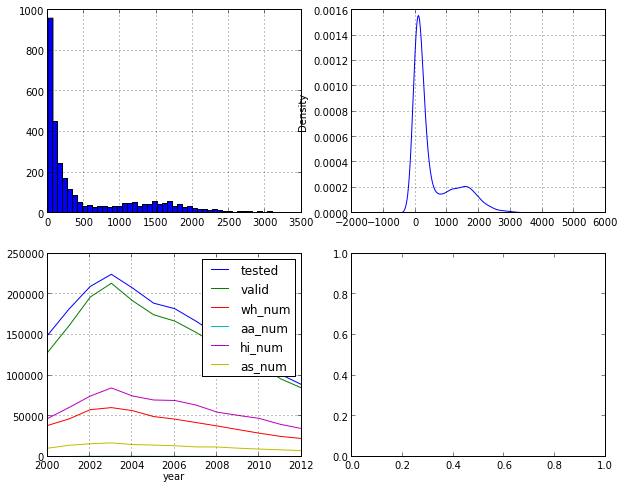

```python
selected = df.loc[ (df['stype'] == 'H')]
grouped = selected.groupby('cds')['tested']

fig, axes = plt.subplots(nrows=2, ncols=2, figsize=(10,8))

grouped.mean().dropna().hist(ax=axes[0,0],bins=50)
grouped.mean().dropna().plot(ax=axes[0,1],kind='kde')
sums.plot(ax=axes[1,0])
```

# Creating Plots

Now that we have a table of data, the next thing to do is plot it.

Explaining how to use Pandas for data analysis is a bit beyond the scope of this introduction, and panels can be complicated. FOr this tutorial, is is most important to know that a panel works like a 3-dimentional structure, where two of the dimensions are CDS -- the school identification number -- and the year. The third is the data columns. Panels provide a convient way to analyze time series.

In particular, with the object `pan`, we can extract a single column. For instance `pan['pct_wh']` extracts a 2-dimensional table of percentages of White test takers, with one entry for each school and each year. Then `pan['pct_wh'].mean()` will compute the mean value for each year across all of the schools. ( If we had set the indices the other way, with `df.set_index(['year','cds'])` then `mean()` would calculate the mean value for each school across the years.

Finally, we will perform this calculation for the four largest racial categories and combine them into a single table.

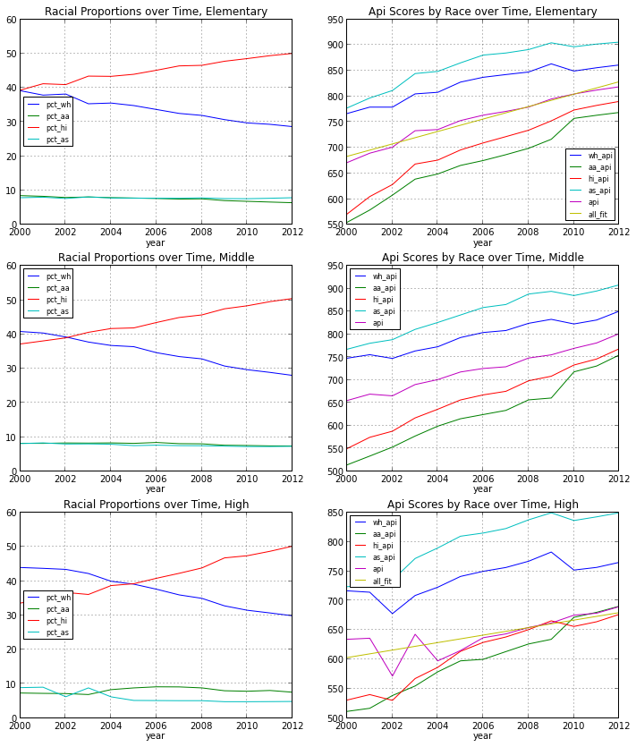

```python
def pct_apis(d, stype):

    selected = d.loc[(df['stype'] == stype )]
    mldf = selected.set_index(['cds','year'])
    pan = mldf.to_panel() # Convert to a time-series panel

    racial_pcts = pd.concat([pan['pct_wh'].mean(), pan['pct_aa'].mean(),pan['pct_hi'].mean(), pan['pct_as'].mean()], axis=1)
    racial_pcts.columns = ['pct_wh', 'pct_aa', 'pct_hi', 'pct_as']

    racial_api = pd.concat([pan['wh_api'].mean(), pan['aa_api'].mean(),pan['hi_api'].mean(), pan['as_api'].mean(),  pan['api'].mean()], axis=1)
    racial_api.columns = ['wh_api', 'aa_api', 'hi_api', 'as_api', 'api']

    return racial_pcts, racial_api

#selected = df.loc[(df['wh_sig'] == 'Yes') & (df['aa_sig'] == 'Yes')  & (df['hi_sig'] == 'Yes') ]
selected   = df

fig, axes = plt.subplots(nrows=3, ncols=2, figsize=(12,14))

#
# Elementary schools
#
e_racial_pcts, e_racial_api = pct_apis(selected, 'E' )

fit_fn = poly1d(polyfit(e_racial_api.index,e_racial_api.api,1)) # Add a regression line
e_racial_api['all_fit'] = fit_fn(e_racial_api.index)

e_racial_pcts.plot(ax=axes[0,0],title='Racial Proportions over Time, Elementary')
axes[0,0].legend(loc='center left', prop={'size':8})
e_racial_api.plot(ax=axes[0,1],title='Api Scores by Race over Time, Elementary')
axes[0,1].legend(loc='lower right', prop={'size':8})

#
# Middle  schools
#
m_racial_pcts, m_racial_api = pct_apis(selected, 'M' )

fit_fn = poly1d(polyfit(e_racial_api.index,e_racial_api.api,1)) # Add a regression line
e_racial_api['all_fit'] = fit_fn(e_racial_api.index)

m_racial_pcts.plot(ax=axes[1,0],title='Racial Proportions over Time, Middle')
axes[1,0].legend(loc='upper left', prop={'size':8})
m_racial_api.plot(ax=axes[1,1],title='Api Scores by Race over Time, Middle')
axes[1,1].legend(loc='upper left', prop={'size':8})

#
# High schools
#

h_racial_pcts, h_racial_api = pct_apis(selected, 'H' )

fit_fn = poly1d(polyfit(h_racial_api.index,h_racial_api.api,1)) # Add a regression line
h_racial_api['all_fit'] = fit_fn(h_racial_api.index)

h_racial_pcts.plot(ax=axes[2,0],title='Racial Proportions over Time, High')
axes[2,0].legend(loc='center left', prop={'size':8})
h_racial_api.plot(ax=axes[2,1],title='Api Scores by Race over Time, High')
axes[2,1].legend(loc='upper left', prop={'size':8})
```

## More Complex Analysis

Subtract out the trend line to make the scores more similar across time, then we'll check that the racial groups across the different school types are near each other. If so, we can just subtract out and fit for the average api score across all of the school types.

```
[  1.21065893e+01  -2.35299846e+04]
[  1.18452903e+01  -2.30378054e+04]
[  6.38064984e+00  -1.21582343e+04]
```

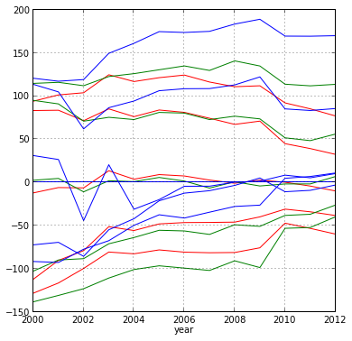

```python
e_pf = polyfit(e_racial_api.index,e_racial_api.api,1)
fit_fn = poly1d(e_pf)

e = e_racial_api.sub(fit_fn(e_racial_api.index),axis=0)

m_pf = polyfit(m_racial_api.index,m_racial_api.api,1)
fit_fn = poly1d(m_pf)

m = m_racial_api.sub(fit_fn(m_racial_api.index),axis=0)

h_pf = polyfit(h_racial_api.index,h_racial_api.api,1)
fit_fn = poly1d(h_pf)

h = h_racial_api.sub(fit_fn(h_racial_api.index),axis=0)

fig, axes = plt.subplots(nrows=1, ncols=1, figsize=(6,6))

print e_pf
print m_pf
print h_pf

e.plot(ax=axes, color='r', legend=False)
m.plot(ax=axes, color='g', legend=False)
h.plot(ax=axes, color='b', legend=False)
```

Look at the relationship between parent education and school performance, after removing the growth trend over the years. Zero on the vertical axis is the average API score agross all years.

The horizontal axis is actually a categorical variable, where 1 means "Didn't graduate from High School", 3 means "Some Degree" and 5 means "Graduate Degree." Because it is categorical, statistics on these values aren't numerically meaningfull, other than general notions of 'more' or 'less.' However, since increasing values do mean the parent has more education, it can show that there is a positive relationship between parent education and API scores.

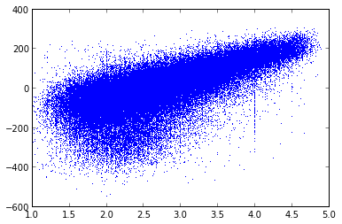

```python
# Select just the columsn we need
sdf = df[['year','api','avg_ed']]

# Get rid of an NaNs
fdf = sdf[np.isfinite(sdf['api'])]

# Create the fit function for linear regression
pf = polyfit(fdf.year,fdf.api,1)
fit_fn = poly1d(pf)

# Add a new column with the fit function subtracted from the api score.
fdf['n_api'] = fdf['api'] - fit_fn(fdf['year'] )

fdf = fdf[fdf['avg_ed'] > 0] # -100 is a code for something ...

# Quantize the average education
fdf['qavg_ed'] = (fdf['avg_ed']+0.5).apply(int)


plot(fdf['avg_ed'],fdf['n_api'], 'b,')
```

Average API scores by parent education category

```python
gdf = fdf.groupby('qavg_ed')
gdf['api'].mean()
```

```
qavg_ed
1          623.123040
2          662.995902
3          749.206718
4          859.892408
5          928.073868
Name: api, dtype: float64
```

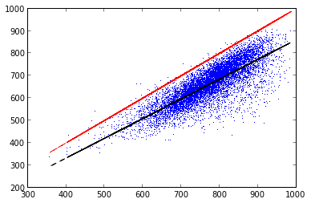

```python
# We need to run the query again to add the significance criteria.
q = """
SELECT
cds, year, api, valid,
aa_num, pct_aa,  aa_api,
wh_num,  pct_wh, wh_api,
hi_num,  pct_hi, hi_api,
as_num,  pct_as, as_api,
el
FROM api_base
WHERE wh_sig = 'Yes' AND aa_sig = 'Yes'
"""

df = p.select(q).pandas
df.head()

x = df.wh_api
y = df.aa_api
fit = polyfit(x,y,1)
fit_fn = poly1d(fit) # fit_fn is now a function which takes in x and returns an estimate for y

plot(x,y, 'b,', x, fit_fn(x), '--k', x,x, '--r')
```

```python
aa_better = df[df.aa_api > df.wh_api]
aa_better.cds.unique()
```

```
array([19643036011605, 33669856031637, 34674056033567, 34674476034599,
        1611926001069, 37683386039655, 10101080000000, 34673306033187,
       34674056033559, 37681146038301, 58727510000000, 58727516056824,
        7100746077168,  7617966004659, 19101991995232, 19647336018790,
       34103480000000, 34674476034623, 34673976033385, 37735696115299,
       19651696023832, 34674396099808, 36103636069348, 39103970000000,
       36738900000000, 37683386039374,  1611766000715,  7100740118208,
        7617546004055,  7617546004162,  7617546004337,  7617626004428,
        7617886004576,  7617966004741, 10621170113563, 10621176100408,
       10621176101984, 10621176120091, 10621660108555, 10621666006118,
       10621666006258, 10621666006522, 10621666006563, 10621666006589,
       10621666057327, 10624146007173, 12626790000000, 13632220000000,
       13632226008643, 15101571530492, 15101576069496, 15633130000000,
       15633216008858, 15633216008999, 15633216009013, 15633216009195,
       15635291530369, 15637506110431, 16638750000000, 16639176010417,
```

[output cut: 155 more lines]